# Adv_GenAI_For_NLP_NewsFindr_Project_Notebook_Sriram_N

[figure not shown]

Artificial Intelligence and Machine Learning

Advanced GenAI for NLP - Project

[figure not shown]

NewsFindr : Redefining news discovery

## Problem Statement

### Business Context

NewsFindr is redefining news discovery by delivering real-time news updates tailored to user interests. Traditional search methods and generic news feeds often lead to information overload and inefficiencies, making it challenging for users to access relevant and trustworthy content efficiently.

To address this, NewsFindr wants to leverage Agentic AI to build an AI-powered news retrieval agent that ensures accuracy and credibility. By utilizing a structured, multi-step approach, the system will provide secure, fair, and explainable recommendations - enhancing user engagement, optimizing content discovery, and improving access to timely and relevant news.

### Objective

- Provide real-time, personalized news retrieval to help users discover relevant content effortlessly.
- Ensure accuracy and credibility by sourcing news from trusted platforms and minimizing misinformation.
- Improve user engagement through seamless content discovery, reducing information overload.
- Streamline the news consumption process by eliminating outdated and irrelevant content, providing a refined reading experience.

## 1. Setting Up the LLM

### 1.1 Verify Installation

**Note** :

- All the required libraries are installed using `uv` on local laptop
- `jupyter` and `tqdm` are installed to run the jupyter notebook locally
- Groq API key has been created and setup using `dotenv` (and is in the `.env` file locally)

```python
# Display the contents of requirements.txt
! cat requirements.txt
```

```
# Core Python / notebook
jupyter
tqdm
numpy

# LangChain modern stack (MLflow-compatible)
langchain-core>=0.3.12
langchain-community>=0.3
langchain-experimental>=0.3
langchainhub
langchain-openai>=0.3
langchain-huggingface>=0.3
langchain-groq>=0.1

# LLM providers
openai

# Utilities
ddgs
python-dotenv

# Tracking
mlflow[langchain]>=2.9
```

```python
# List the installed packages on uv env to verify installations
!uv pip list
```

[output not shown]

[output cut: 165 more lines]

[output not shown]

### 1.2 Import Libraries

```python
# Import necessary libraries
import json
import os
# Suppress DeprecationWarnings
import warnings

# DuckDuckGo Search imports
from ddgs import DDGS

# Import dotenv to manage environment variables
from dotenv import load_dotenv

# LangChain imports
from langchain.agents import create_agent
from langchain_core.messages import SystemMessage, HumanMessage
from langchain_groq import ChatGroq

warnings.filterwarnings("ignore", category=DeprecationWarning)
```

### 1.3 Local MLFlow Setup for LangChain Trace Logging

- A local MLFlow server has been set up and is running on port 5000 to trace the tool calls and LLM invocations.
- This helped in monitoring and analyzing the interactions of the LLM and tools used in the agent.
- MLFlow tracing and logs helped in optimising the tool calls and LLM invocations by fine tuning the prompts and system messages.

```python
# Initialize MLflow for LangChain to trace logging
import mlflow

# Calling autolog for LangChain will enable trace logging.
mlflow.langchain.autolog()
```

```python
# Setup MLFlow experiment and tracking URI to trace the tool calls and LLM invocations
# Note : MLFlow server is setup and running locally on port 5000
mlflow.set_experiment("NewsFindr_AgenticAI_Experiment")
mlflow.set_tracking_uri("http://127.0.0.1:5000")

# disable notebook display for MLFlow traces
mlflow.tracing.disable_notebook_display()
```

[output not shown]

### 1.4 Load a LLM using Groq

#### 1.4.1 Load Groq API Key

```python
# Load environment variables from .env file
load_dotenv()
```

```
True
```

```python
# Load environment variables from .env file
groq_api_key = os.environ["GROQ_API_KEY"]

# verify if the Groq API key is loaded correctly
print("Groq API Key Loaded:", groq_api_key is not None)
```

```
Groq API Key Loaded: True
```

#### 1.4.2 Initializes Groq models with different temperature settings.

- Two models are initialized using Groq's ChatGroq class:
  - A high creativity model with a temperature of 0.8 for generating diverse and creative responses.
  - A low creativity (deterministic) model with a temperature of 0.0 for consistent and accurate responses.

```python
# set the model name
model_name = "llama-3.3-70b-versatile"
# High creativity LLM with a temperature of 0.8 using Groq
llm_high = ChatGroq(
    model=model_name,
    temperature=0.8
)

# Low creativity (deterministic) LLM with a temperature of 0.0 using Groq
llm = ChatGroq(
    model=model_name,
    temperature=0.0
)
```

### 1.3 Checking LLMs response for a simple query

Both the high and low temperature models are tested with a simple question to observe the differences in their responses.

#### 1.3.1 Low temperature Model response

- A low temperature setting ensures consistent and repeatable responses, making the output more deterministic. It is ideal for tasks requiring accuracy, such as fact-based queries, structured data extraction, and rule-based decision-making.

```python
# Check response from low temperature LLM by asking a simple question that requires factual accuracy
response = llm.invoke("How many countries played the FIFA World Cup 2022?")
print(response)
```

```
content='A total of 32 countries played in the FIFA World Cup 2022, which was held in Qatar from November 20 to December 18, 2022.' additional_kwargs={} response_metadata={'token_usage': {'completion_tokens': 35, 'prompt_tokens': 47, 'total_tokens': 82, 'completion_time': 0.078833361, 'completion_to…
```

#### 1.3.2 High temperature Model response

- A high temperature setting introduces more randomness and variability in responses, making the output creative and diverse. It is useful for tasks like brainstorming, storytelling, content generation, and exploring multiple perspectives.

```python
# Check response from high temperature LLM by asking a simple question that requires factual accuracy
response = llm_high.invoke("what are the different perspectives about spotting UFOs?")
print(response)
```

```
content='There are several different perspectives about spotting UFOs (Unidentified Flying Objects), which can be broadly categorized into the following:\n\n1. **Skeptical Perspective**: Many scientists and experts approach UFO sightings with a healthy dose of skepticism, arguing that most reported …
```

- From the above questions to the 2 models, we can see that the low temperature model provides a precise and factual answer, while the high temperature model offers a more creative and varied response.

## 2. SQL Agent for Data Retrieval

Facilitates efficient data retrieval and modification, enabling seamless customer information management through SQL interactions

### 2.1 Initialise SQL Agent and System Message

- Initializes an AI-powered SQL agent for querying and updating a database.
- It connects to an SQL database, and sets up an agent and check for the presence of the email in the DB,
  - if not found return as "email not found"
  - if email found return with the "name of the customer and area of interest".

````python
# Import necessary modules for SQL agent
from langchain_community.utilities import SQLDatabase
from langchain_community.agent_toolkits import SQLDatabaseToolkit

# Load the SQLite customer database
db = SQLDatabase.from_uri("sqlite:///customer.db")

#Initialize the system message
db_dialect = db.dialect

system_message = f"""You are an agent with expertise in SQL and designed to interact with a Customer database (in SQLite).

### STEPS to follow:
1. To start you should ALWAYS look at the tables in the database to see what you can query. Do NOT skip this step.
2. Given an input by the user in natural language, create a syntactically correct {db_dialect} query to run.
3. If the email provided by the user in the input is NOT FOUND in the database, return : "email not found".
4. If the email IS FOUND, return the customer's name and their interests in a dictionary format as shown below:
    ```
    {{ "name": "<customer_name>", "interests": [<list_of_interests>]}}
    ```

### NOTE
- STRICTLY follow the above instructions for all queries related to email IDs from the user.
- STRICTLY never return a SQL query. Return only the response.
- For queries that require multiple records, ensure to fetch them without filtering or limiting the results.
- Do not provide any additional information or explanations beyond the specified response format.

### Relevance Check
When providing answers, ensure to:
- Evaluate whether the response addresses the user's question and is in the expected format.
"""

#Initialize the toolkit with customer database and the LLM
toolkit = SQLDatabaseToolkit(db=db, llm=llm)

# Get the tools from the toolkit
tools = toolkit.get_tools()

#Create the SQL agent with the system message
db_agent = create_agent(
    model=llm,
    tools=tools,
    system_prompt=system_message,
)
````

### 2.2 Queries to verify customer information

```python
# utility function to print the conversation message log of the agent
def print_conversation(messages):
    for msg in messages:
        msg.pretty_print()
```

#### 2.2.1 Fetch all unique email ids from the database

```python
# query to fetch all unique email ids from the database
query = f"Fetch all the unique email_id"

# store the output of the query
output = db_agent.invoke({
    "messages" : [{"role": "user", "content": query}]
})

# Display the unique email ids from the last AIMessage content in the output
output['messages'][-1].pretty_print()
```

```
================================== Ai Message ==================================

Here are all the unique email_id(s) from the customers table:

1. alice.6eb33c45-5@gmail.com
2. alice.d56e53b6-1@gmail.com
3. emma.a88fec03-c@gmail.com
4. george.5483cb53-8@gmail.com
5. hannah.4770b814-2@gmail.com
6. ian.203631a0-b@gmail.com
7. ian.aee37571-7@gmail.com
8. julia.b5a14512-c@gmail.com
9. julia.cf4d1edb-9@gmail.com
10. julia.d77d96f3-3@gmail.com
11. kevin.f8641860-7@gmail.com
12. lily.45e01919-0@gmail.com
13. lily.fa8fe05b-7@gmail.com
14. nora.c63fa237-e@gmail.com
15. oscar.edd38e10-6@gmail.com
```

```python
# Display the messages conversation log
print_conversation(output['messages'])
```

````
================================ Human Message =================================

Fetch all the unique email_id
================================== Ai Message ==================================
Tool Calls:
  sql_db_query_checker (4tkv8bhee)
 Call ID: 4tkv8bhee
  Args:
    query: SELECT DISTINCT email_id FROM customers
  sql_db_query (e3rcmbvsb)
 Call ID: e3rcmbvsb
  Args:
    query: SELECT DISTINCT email_id FROM customers
================================= Tool Message =================================
Name: sql_db_query_checker

```sql
SELECT DISTINCT email_id FROM customers
```
================================= Tool Message =================================
Name: sql_db_query

Error: (sqlite3.OperationalError) no such column: email_id
[SQL: SELECT DISTINCT email_id FROM customers]
(Background on this error at: https://sqlalche.me/e/20/e3q8)
================================== Ai Message ==================================
Tool Calls:
  sql_db_schema (p6pgwsthw)
 Call ID: p6pgwsthw
  Args:
    table_names: customers
================================= Tool Message =================================
Name: sql_db_schema


CREATE TABLE customers (
	id INTEGER,
	customer_id TEXT NOT NULL,
	name TEXT NOT NULL,
	email TEXT NOT NULL,
````

[output cut: 58 more lines]

```
1. alice.6eb33c45-5@gmail.com
2. alice.d56e53b6-1@gmail.com
3. emma.a88fec03-c@gmail.com
4. george.5483cb53-8@gmail.com
5. hannah.4770b814-2@gmail.com
6. ian.203631a0-b@gmail.com
7. ian.aee37571-7@gmail.com
8. julia.b5a14512-c@gmail.com
9. julia.cf4d1edb-9@gmail.com
10. julia.d77d96f3-3@gmail.com
11. kevin.f8641860-7@gmail.com
12. lily.45e01919-0@gmail.com
13. lily.fa8fe05b-7@gmail.com
14. nora.c63fa237-e@gmail.com
15. oscar.edd38e10-6@gmail.com
```

##### Observations

- From the above chat conversation we can understand that the Agent makes multiple calls with different column names in the SQL queries to fetch the email ids from the database.
- Finally it returns the unique email ids (15 in total) present in the database after getting the results from the SQL queries.
- The tool invocation and LLM calls are available in the logs

#### 2.2.2 Fetch non-existent email id from the database

```python
# set the email id that is not present in the database
email = "bob.9999-abcd@gmail.com"

query = f"Fetch all records with email_id {email}"

# store the output of the query
output = db_agent.invoke({
    "messages" : [{"role": "user", "content": query}]
})

# Display the unique email ids from the last AIMessage content in the output
output['messages'][-1].pretty_print()
```

```
================================== Ai Message ==================================

email not found
```

```python
# Display the messages conversation log
print_conversation(output['messages'])
```

````
================================ Human Message =================================

Fetch all records with email_id bob.9999-abcd@gmail.com
================================== Ai Message ==================================
Tool Calls:
  sql_db_query_checker (gbqdsndb2)
 Call ID: gbqdsndb2
  Args:
    query: SELECT * FROM customers WHERE email_id = 'bob.9999-abcd@gmail.com'
  sql_db_query (xveacxmw1)
 Call ID: xveacxmw1
  Args:
    query: SELECT * FROM customers WHERE email_id = 'bob.9999-abcd@gmail.com'
================================= Tool Message =================================
Name: sql_db_query_checker

```sql
SELECT * FROM customers WHERE email_id = 'bob.9999-abcd@gmail.com'
```
================================= Tool Message =================================
Name: sql_db_query

Error: (sqlite3.OperationalError) no such column: email_id
[SQL: SELECT * FROM customers WHERE email_id = 'bob.9999-abcd@gmail.com']
(Background on this error at: https://sqlalche.me/e/20/e3q8)
================================== Ai Message ==================================
Tool Calls:
  sql_db_schema (bntz5278j)
 Call ID: bntz5278j
  Args:
    table_names: customers
================================= Tool Message =================================
Name: sql_db_schema


CREATE TABLE customers (
	id INTEGER,
	customer_id TEXT NOT NULL,
	name TEXT NOT NULL,
	email TEXT NOT NULL,
````

[output cut: 24 more lines]

````
================================= Tool Message =================================
Name: sql_db_query_checker

```sql
SELECT name, interests
FROM customers
WHERE email = 'bob.9999-abcd@gmail.com'
```
================================= Tool Message =================================
Name: sql_db_query


================================== Ai Message ==================================

email not found
````

##### Observations

- The Agent has responded correctly with "email not found" as the email id `bob.9999-abcd@gmail.com` is not present in the database.

#### 2.2.3 Fetch existing email id from the database

```python
# set the email id that is present in the database
email = "alice.6eb33c45-5@gmail.com"

# set the query to fetch all interests for the given email id
query = f"Fetch all the Interests with email_id {email} in a list."

# store the output of the query
output = db_agent.invoke({
    "messages" : [{"role": "user", "content": query}]
})

# Display the unique email ids from the last AIMessage content in the output
output['messages'][-1].pretty_print()
```

```
================================== Ai Message ==================================

{"name": "Alice", "interests": ["Politics", "Technology", "Business"]}
```

```python
# print the messages conversation log
print_conversation(output['messages'])
```

````
================================ Human Message =================================

Fetch all the Interests with email_id alice.6eb33c45-5@gmail.com in a list.
================================== Ai Message ==================================
Tool Calls:
  sql_db_list_tables (djhwwvqby)
 Call ID: djhwwvqby
  Args:
  sql_db_query_checker (bhwhqyqar)
 Call ID: bhwhqyqar
  Args:
    query: SELECT Interests FROM Customers WHERE email_id = 'alice.6eb33c45-5@gmail.com'
  sql_db_query (xtnw0tzn5)
 Call ID: xtnw0tzn5
  Args:
    query: SELECT Interests FROM Customers WHERE email_id = 'alice.6eb33c45-5@gmail.com'
================================= Tool Message =================================
Name: sql_db_list_tables

customers
================================= Tool Message =================================
Name: sql_db_query_checker

```sql
SELECT Interests
FROM Customers
WHERE email_id = 'alice.6eb33c45-5@gmail.com'
```
================================= Tool Message =================================
Name: sql_db_query

Error: (sqlite3.OperationalError) no such column: email_id
[SQL: SELECT Interests FROM Customers WHERE email_id = 'alice.6eb33c45-5@gmail.com']
(Background on this error at: https://sqlalche.me/e/20/e3q8)
================================== Ai Message ==================================
Tool Calls:
  sql_db_schema (aw9fkve8f)
 Call ID: aw9fkve8f
  Args:
    table_names: Customers
````

[output cut: 14 more lines]

````
================================= Tool Message =================================
Name: sql_db_query_checker

```sql
SELECT interests
FROM customers
WHERE email = 'alice.6eb33c45-5@gmail.com'
```
================================= Tool Message =================================
Name: sql_db_query

[('["Politics", "Technology", "Business"]',)]
================================== Ai Message ==================================

{"name": "Alice", "interests": ["Politics", "Technology", "Business"]}
````

##### Observations

- The Agent has responded correctly with the list of interests for the email id `alice.6eb33c45-5@gmail.com` as `["Politics", "Technology", "Business"]`

## 3. Interface between SQL and Search Agents

### 3.1 Generating Expanded Search Queries for Current News

This function `expand_search_queries`, generates precise and up-to-date search queries based on the user's interests. It ensures that each query is crafted to retrieve breaking news, trending topics, or recent developments without relying on specific years.

The function takes user `interests` and `user_query` as inputs and processes through an LLM to generate a relevant search query.

A system prompt guides the model to focus only on current events and avoid outdated information.

The expanded search queries are stored in `expanded_queries` and returned for later use in retrieving news articles.

```python
# Import the langchain tool decorator and datetime
from langchain.tools import tool
from datetime import datetime

# Function to expand search queries based on user interests
@tool("ExpandSearchQueries", description="Expands user interests into precise, time-sensitive news search queries based on a user query.")
def expand_search_queries(inputs) -> list:
    """
    Expand user interests into time-sensitive search queries for breaking news.
    Accepts either a dict (with 'interests' and 'user_query') or a raw string.
    """
    # Handle dict input
    if isinstance(inputs, dict):
        interests = inputs.get("interests", [])
        user_query = inputs.get("user_query", "")
    else:
        # Handle string input fallback
        interests = [i.strip() for i in str(inputs).split(",")]
        user_query = ""

    current_year = datetime.now().year

    system_prompt = f"""You are a search query generator.
You are focused on creating precise and up-to-date search queries based on the user's interests {interests} and user query '{user_query}'. Your search queries should retrieve breaking news, trending topics, or recent developments.

Your queries should:
- be highly specific to the interests area. For multiple interests, generate separate queries for each interest.
- relevant to user's request.
- time-sensitive with no outdated references.
- avoid using specific years or outdated references in your queries.

Response :
- Return only the search query text without any additional explanation.
Reference :
- Current Year is {current_year}.
    """

    expanded_queries = []
    for interest in interests:
        prompt = f"Generate one search query related to: '{interest}' considering the user query: '{user_query}'"
        messages = [
            SystemMessage(content=system_prompt),
            HumanMessage(content=prompt)
        ]
        response = llm.invoke(messages)
        query = response.content.strip()
        if query:
            expanded_queries.append(query)
    return expanded_queries
```

### 3.2 Fetch News Results Using DuckDuckGo

This function retrieves news results from DuckDuckGo based on the user's expanded search queries.

```python
# function to perform DuckDuckGo search and return top 5 results
@tool("DuckDuckGoSearch", description="Searches DuckDuckGo for news articles from the past week and returns top 5 results with URLs.")
def ddg_search(query: str) -> str:
    """
    Performs a DuckDuckGo search for the given query and returns the top 5 results.
    The search is limited to the past week to ensure recency.
    Args:
        query (str): User's expanded search query string.
    Returns:
        list: A list of dictionaries containing title, url, and body of each search result.
    """
    results = []

    with DDGS() as ddgs:
        for r in ddgs.text(query, max_results=5, timelimit='w'):
            title = r.get("title", "")
            url = r.get("href", "")
            body = r.get("body", "")
            res = {"title": title, "url": url, "body": body}
            results.append(res)
    return results
```

### 3.3 Filter Relevant and Trustworthy URLs Based on User Interests

This function filters search result URLs, assesses the credibility of news sources, and retains only those that are relevant to the user's interests.

Extracts URLs and their body content from the search results.

Updates the state with the refined list of relevant URLs and their descriptions.

```python
# function to filter search results using LLM for credibility and relevance
@tool("CredibilityFilter", description="Filters search results by evaluating URL credibility, relevance to user interests, and recency using LLM.")
def filter_with_llm(search_results: list, interests: list) -> list:
    """
    Filters search results using LLM based on credibility of news source, relevance to user interests, and recency. Returns filtered results with URLs and body content in JSON format.
    :param search_results: List of search results from Search tool.
    :param interests: List of user interests as string to check relevance against.
    :return: Filtered list of credible and relevant search results with URLs and body content in JSON format.
    """
    search_results = json.dumps(search_results, indent=2)

    # Get today's date to enforce recency
    today = datetime.today().strftime('%Y-%m-%d')

    system_prompt = f"""You are an evaluator of search results provided to you.
Your evaluation criteria should focus on
1. Credibility of the news source
2. Relevance to user interests {interests}. For multiple interests, ensure the content is relevant to at least one interest.
3. Recency of the news articles

Few Considerations while evaluating:
1. Iterate through each search result
2. For each result,
    - Keep only credible news from recognized outlets
    - Remove low-quality, spam, or unreliable sources
    - Verify content is relevant to user interests
    - Remove articles from previous year or earlier

Response :
- For each credible and relevant article that meets the above criteria,
    - Extract the URLs and the body content from the filtered search results
    - Update the response with a list of dictionaries containing 'url' and 'body' only.
- Return the response without any additional explanation.

Reference :
- Today is {today}.

Evaluation : Evaluate the following aspects STRICTLY before returning the results:
1. Relevance Check : Are the filtered results addressing the user's interests and are from credible sources, and are recent ?
2. Groundedness Check : Are the filtered search results well-grounded in the retrieved context, without hallucination or unsupported claims ?
3. Format : Return the results as a list of dictionaries in JSON format with 'url' and 'body' only. Validate the JSON format before returning.
"""
    prompt = f"""Evaluate these below search results by filtering based on credibility of sources, relevance to user interests, and recency:

    {search_results}
"""

    messages = [
        SystemMessage(content=system_prompt),
        HumanMessage(content=prompt)
    ]

    response = llm.invoke(messages)
    return response.content
```

## 4. Output from LLMs

### 4.1 Generate summary for the URLs

This function generates summaries for the credible URLs

Returns the URLs and the Summary based on the users interest

```python
# function to summarize news from a list of URLs
@tool("SummarizeNews", description="Generates summaries from news URLs and returns both the summaries and the links.")
def summarize_news(url_list) -> dict:
    """
    Summarizes key news points from a list of URLs and returns both the summary and its corresponding URL. Summary will be for each URL provided.
    :param url_list: List of credible URLs to summarize in string format.
    :return: Dictionary containing list of 'summaries' and list of corresponding 'urls'.
    """

    system_prompt = """You are a news summarizer and your task is to generate concise summaries from a list of news URLs. For each URL, provide a summary.

High level steps for generating summary per URL :
- Iterate through each URL
- Generate a summary for that URL based on,
    - Key news topics based on the domain reputation and URL structure
    - Any contextual information available

Each summary should :
- Be structured as a plain text sentence.
- Be specific with actual information (if present), and should not contain generic statements."
- Focus on key facts, developments, and insights from the URLs.

Response should contain the summary list in the same order as the URLs, without any additional explanation.

Evaluation : Evaluate the following aspects STRICTLY before returning the results:
1. Relevance Check : Are the summaries reflecting the key news points from the URLs provided ?
2. Groundedness Check : Are the summaries well-grounded in the URL context, without hallucination or unsupported claims ?
3. Format : Return the response as a text list of summaries per url. Validate the response order before returning with the requested list of URLs.
"""

    # Pass the URLs to the LLM for summarization
    prompt = f"""Based on the website domains and URL context, generate the summary of the key news points from the each of the following URLs:"

{url_list}

    """

    messages = [
        SystemMessage(content=system_prompt),
        HumanMessage(content=prompt)
    ]

    response = llm.invoke(messages)

    summary_text = response.content

    # Return a dictionary containing the summary and the original list of URLs
    return {"summary": summary_text, "urls": url_list}
```

### 4.2 Creating an Agent

```python
# Initialize the agent with the defined tools
tools = [
    expand_search_queries,
    ddg_search,
    filter_with_llm,
    summarize_news]

system_prompt = """You are an AI-powered news retrieval agent designed to provide users with accurate and credible news summaries based on their interests and queries.

### Tools Available:
You have access to the following tools:

1. ExpandSearchQueries: Expands user interests into precise, time-sensitive news search queries.
2. DuckDuckGoSearch: Searches DuckDuckGo for news articles from the past week and
3. CredibilityFilter: Filters search results by evaluating URL credibility, relevance to user interests, and recency using LLM.
4. SummarizeNews: Generates summaries from news URLs and returns both the summaries and the links.
Your goal is to use these tools effectively to deliver relevant news summaries and verified URLs to users based on their specified interests and queries.

### Workflow:
Execute these steps in the following order:
1. Use 'ExpandSearchQueries' tool with: {{'interests': {interests}, 'user_query': '{user_query}'}}
    - Collect the generated expanded search queries

2. For each expanded query, use 'DuckDuckGoSearch' tool to get the recent, top 5 news articles based on the user's interests and query.
    - Collect all search results returned from the tool.

3. Combine ALL search results from 'DuckDuckGoSearch' tool and pass to 'CredibilityFilter' tool.
    - Collect all the filtered results containing the urls and body content, returned by the tool.

4. Invoke 'SummarizeNews' tool by passing only the filtered URLs returned by `CredibilityFilter` tool
    - Collect the summary and the source URLs returned by the tool.

5. Present the final summary and URLs in a clean, readable format:
 - Summary section with key points
 - URLs section with clickable links

### Note:
- DO NOT MAKE PARALLEL CALLS to the tools and strictly EXECUTE THEM SEQUENTIALLY as per the defined workflow.

### Evaluation
1. Relevance Check : Are the final summary and URLs addressing the user's interests and query ?
2. Groundedness Check : Are the final summary and URLs well-grounded in the retrieved context, without hallucination or unsupported claims ?
3. Format : Present the final response in a clean, readable format with a summary section and a URLs section.

"""
# Create the agent using the low temperature LLM and the defined tools
agent = create_agent(
    tools=tools,
    model=llm,
    system_prompt=system_prompt,
)
```

### 4.3 Invoking the Agent with User Interests and Query

- Display Final Verified URLs and Summary based on the User interest and User query

#### 4.3.1 Fetch User Interests from SQL Agent

```python
# Import ast to parse string representation of dictionary
import ast

# Final code
email = "julia.b5a14512-c@gmail.com"

# Fetch interests based on the provided email
query = f"Fetch all the Interests with email_id {email} in a list"

# invoke the db_agent to get the interests
interest_result = db_agent.invoke({
    "messages" : [{"role": "user", "content": query}]
})

# Extract the AI message containing the name and interests as a dictionary
interest_output = interest_result['messages'][-1].content
interest_dict = ast.literal_eval(interest_output)
interests = interest_dict.get("interests", [])
interests
```

```
['India', 'Entertainment']
```

#### 4.3.2 Invoking the News Retrieval Agent

```python
# Define the user query
user_query = "India current affairs and political developments"

# Agent prompt stays the same, just note we’re passing the dict
today = datetime.today().strftime('%Y-%m-%d')
agent_prompt = f""" The user's interests are: {interests} and they are specifically looking for {user_query}.

Provide the relevant, latest news articles and summaries based on the user's interests and query.

Reference : Today is {today}.
"""

response = agent.invoke({
    "messages" : [{"role": "user", "content": agent_prompt}]
})

print("\n======= FINAL RESPONSE FROM AGENT =======")
response['messages'][-1].pretty_print()
```

```
======= FINAL RESPONSE FROM AGENT =======
================================== Ai Message ==================================

### Summary
* India celebrates Republic Day with Modi and BJP in attendance, while Rahul Gandhi and Congress participate in events, amidst updates on Trump, Greenland, tariffs, and EU, along with weather and BMC elections.
* Reuters provides in-depth coverage of India-related news, including politics, business, and social issues, offering a comprehensive overview of the country's current events.
* The National Herald reports on national news in India, covering topics such as politics, economy, and social issues, with a focus on in-depth analysis and commentary.
* NDTV delivers the latest news from India, including updates on politics, sports, entertainment, and more, with a focus on breaking news and live coverage.
* ANI News provides national news updates from India, covering a range of topics including politics, business, sports, and entertainment, with a focus on news as it happens.
* Bollywood celebrities cast their votes in the 2026 Maharashtra civic polls, as the BMC elections see participation from various personalities, amidst a high voter turnout in the state.

### URLs
1. https://economictimes.indiatimes.com/news/newsblogs/world-india-news-live-updates-trump-greenland-tariffs-eu-republic-day-modi-bjp-rahul-gandhi-congress-weather-bmc-elections/liveblog/126635902.cms
2. https://www.reuters.com/world/india/
3. https://www.nationalheraldindia.com/section/national
4. https://www.ndtv.com/latest
5. https://www.aninews.in/category/national/
6. https://www.msn.com/en-in/news/India/bmc-elections-2026-bollywood-celebrities-cast-their-vote-in-maharashtra-civic-polls/vi-AA1UgxL0
```

#### 4.3.3 Conversation log with tool calls, LLM invocations

Note : This is added as

1. the new langchain version supports logging of tool calls and LLM invocations in the message log of the agent.
2. the earlier verbose argument is deprecated in the latest langchain version.

```python
# Display the messages conversation log
print_conversation(response['messages'])
```

```
================================ Human Message =================================

 The user's interests are: ['India', 'Entertainment'] and they are specifically looking for India current affairs and political developments.

Provide the relevant, latest news articles and summaries based on the user's interests and query.

Reference : Today is 2026-01-18.

================================== Ai Message ==================================
Tool Calls:
  ExpandSearchQueries (a9mxxcf7b)
 Call ID: a9mxxcf7b
  Args:
    inputs: {'interests': ['India', 'Entertainment'], 'user_query': 'India current affairs and political developments'}
================================= Tool Message =================================
Name: ExpandSearchQueries

["\"India latest news updates political developments\"", "\"Indian celebrities reactions to current political events\""]
================================== Ai Message ==================================
Tool Calls:
  DuckDuckGoSearch (qgx716qte)
 Call ID: qgx716qte
  Args:
    query: India latest news updates political developments
  DuckDuckGoSearch (0hag5tecb)
 Call ID: 0hag5tecb
  Args:
    query: Indian celebrities reactions to current political events
================================= Tool Message =================================
Name: DuckDuckGoSearch

[{"title": "India News Live Updates: Congress has lost public trust, lacks ...", "url": "https://economictimes.indiatimes.com/news/newsblogs/world-india-news-live-updates-trump-greenland-tariffs-eu-republic-day-modi-bjp-rahul-gandhi-congress-weather-bmc-elections/liveblog/126635902.cms", "body": "In…
================================= Tool Message =================================
Name: DuckDuckGoSearch

[{"title": "Aamir Khan - Wikipedia", "url": "https://en.wikipedia.org/wiki/Aamir_Khan", "body": "2 days ago · Aamir Hussain Khan is an Indian actor, filmmaker, and television personality who works in Hindi films. Referred to as \"Mr. Perfectionist\" in the media, ..."}, {"title": "BMC elections 2026…
================================== Ai Message ==================================
Tool Calls:
  CredibilityFilter (8kyttncj0)
 Call ID: 8kyttncj0
```

[output cut: 44 more lines]

```
### Summary
* India celebrates Republic Day with Modi and BJP in attendance, while Rahul Gandhi and Congress participate in events, amidst updates on Trump, Greenland, tariffs, and EU, along with weather and BMC elections.
* Reuters provides in-depth coverage of India-related news, including politics, business, and social issues, offering a comprehensive overview of the country's current events.
* The National Herald reports on national news in India, covering topics such as politics, economy, and social issues, with a focus on in-depth analysis and commentary.
* NDTV delivers the latest news from India, including updates on politics, sports, entertainment, and more, with a focus on breaking news and live coverage.
* ANI News provides national news updates from India, covering a range of topics including politics, business, sports, and entertainment, with a focus on news as it happens.
* Bollywood celebrities cast their votes in the 2026 Maharashtra civic polls, as the BMC elections see participation from various personalities, amidst a high voter turnout in the state.

### URLs
1. https://economictimes.indiatimes.com/news/newsblogs/world-india-news-live-updates-trump-greenland-tariffs-eu-republic-day-modi-bjp-rahul-gandhi-congress-weather-bmc-elections/liveblog/126635902.cms
2. https://www.reuters.com/world/india/
3. https://www.nationalheraldindia.com/section/national
4. https://www.ndtv.com/latest
5. https://www.aninews.in/category/national/
6. https://www.msn.com/en-in/news/India/bmc-elections-2026-bollywood-celebrities-cast-their-vote-in-maharashtra-civic-polls/vi-AA1UgxL0
```

## 5. Retrieve URLs and Summaries for Three Areas of Interest

### 5.1 Function to get the final response from the agent based on email and user query

```python
# function to get the final response from the agent based on email and user query
def query_response(email: str, user_query: str) -> str:
    # Fetch interests based on the provided email
    query = f"Fetch all the Interests with email_id {email} in a list"

    # invoke the db_agent to get the interests
    interest_result = db_agent.invoke({
        "messages" : [{"role": "user", "content": query}]
    })

    # Extract the AI message containing the name and interests as a dictionary
    interest_output = interest_result['messages'][-1].content
    interest_dict = ast.literal_eval(interest_output)
    interests = interest_dict.get("interests", [])

    # Agent prompt stays the same, just note we’re passing the dict
    today = datetime.today().strftime('%Y-%m-%d')
    agent_prompt = f""" The user's interests are: {interests} and they are specifically looking for {user_query}.

    Provide the relevant, latest news articles and summaries based on the user's interests and query.

    NOTE : Select the top 3 latest news articles for summarization from the filtered URLs returned by `CredibilityFilter` tool

    Reference : Today is {today}.
    """

    response = agent.invoke({
        "messages" : [{"role": "user", "content": agent_prompt}]
    })

    print("\n======= FINAL RESPONSE FROM AGENT =======")
    response['messages'][-1].pretty_print()

    return response
```

### 5.2 Function to evaluate the Agent response for relevance and groundedness

```python
# function to evaluate the Agent response for relevance and groundedness
def evaluate_agent_response(response, interests, user_query):
    """
    Evaluate the final response from the agent for relevance and groundedness.
    """
    system_prompt = f"""You are an evaluator of the final response provided by an AI-powered news retrieval agent.

Your evaluation criteria should focus on:
1. Relevancy Check : Does the final response address the user's specific query {user_query} and interests {interests} ?
2. Groundedness Check : Is the final response well-grounded in the retrieved context, without hallucination or unsupported claims ?

The final response received from the NewsFindr agent is as follows:
{response}

Expected Response :
- Provide a concise evaluation of the final response based on the above criteria.
- Ensure the response format is JSON with 2 fields: "relevance" and "groundedness", each containing a short concise evaluation statement.

Note :
- Reduce verbosity and focus on key evaluation points only. Do not provide any additional information or explanations beyond the specified response format.
"""


    prompt = f"""Evaluate the final response based on relevance to user interests and query, and groundedness in retrieved context.
"""

    messages = [
        SystemMessage(content=system_prompt),
        HumanMessage(content=prompt)
    ]

    eval_response = llm.invoke(messages)
    return eval_response.content
```

### 5.3 Test the Agent for 3 different users

```python
# Check for the user ID
email = "ian.aee37571-7@gmail.com"
user_query = "Startup News"
response = query_response(email, user_query)
```

```
======= FINAL RESPONSE FROM AGENT =======
================================== Ai Message ==================================

**Summary:**
* The fastest-growing creator economy tech startups are leveraging platforms like Landbase to build and monetize their digital presence, with a focus on community-driven marketplaces and social commerce.
* Seedtable has compiled a list of the best media and entertainment startups, featuring companies that are innovating in areas such as virtual events, social media, and content creation, with a focus on startups that are disrupting traditional industry models.
* Electric vehicle startups are gaining attention this year, with companies like Rivian, Lucid, and Fisker vying for market share and investment, as the industry shifts towards more sustainable and environmentally-friendly transportation options, according to a report by NBC News.

**URLs:**
1. https://www.landbase.com/blog/fastest-growing-creator-economy-tech
2. https://www.seedtable.com/best-media-and-entertainement-startups
3. https://www.nbcnews.com/business/autos/are-electric-vehicle-startups-vying-attention-year-rcna10360
```

````python
# Evaluate the agent response for relevance and groundedness
evaluation_result = evaluate_agent_response(
    response['messages'][-1].content,
    ["Startups"],
    user_query)
evaluation_result = evaluation_result.replace("```", "").strip()
evaluation_result
````

```
'json\n{\n  "relevance": "The final response is relevant to the user\'s query and interests in \'Startups\', covering various aspects such as creator economy, media and entertainment, and electric vehicle startups.",\n  "groundedness": "The final response is well-grounded in the retrieved context, w…
```

#### Test Case 2 : Indian Politics

```python
#Check for the user ID
email = "lily.45e01919-0@gmail.com"  #
user_query = "Top Stories from Indian Politics"
response2 = query_response(email, user_query)
```

```
======= FINAL RESPONSE FROM AGENT =======
================================== Ai Message ==================================

**Summary:**
* The Economic Times reports on the latest political news in India, covering various developments and updates from the country's political landscape.
* Reuters provides in-depth coverage of global news, with a focus on India, including stories on politics, business, and social issues affecting the country.
* Outlook India reports that the BMC election results are expected to show a sweep by the BJP and Shiv Sena alliance, according to exit polls, with vote counting set to begin soon.

**URLs:**
1. https://economictimes.indiatimes.com/news/politics
2. https://www.reuters.com/world/india/
3. https://www.outlookindia.com/elections/bmc-results-2026-live-updates-vote-counting-to-begin-soon-exit-polls-predict-a-bjp-shiv-sena-sweep
```

````python
# Evaluate the agent response for relevance and groundedness
evaluation_result = evaluate_agent_response(
    response2['messages'][-1].content,
    ["India", "Politics"],
    user_query)
evaluation_result = evaluation_result.replace("```", "").strip()
evaluation_result
````

```
'json\n{\n  "relevance": "The final response is highly relevant to the user\'s query, addressing \'Top Stories from Indian Politics\' and aligning with the specified interests [\'India\', \'Politics\'].",\n  "groundedness": "The final response is well-grounded in the retrieved context, providing spe…
```

#### Test Case 3 : Sports

```python
#Check for the user ID
email = " julia.cf4d1edb-9@gmail.com"
user_query = "Top news from Cricketing World"
response3 = query_response(email, user_query)
```

```
======= FINAL RESPONSE FROM AGENT =======
================================== Ai Message ==================================

**Summary:**
* ESPN Cricinfo reports on the latest cricket news, including updates on international matches, player injuries, and tournament schedules.
* NDTV Sports provides news and updates on cricket, covering recent matches, scores, and analysis from around the world, with a focus on the Indian cricket team.
* The Times of India offers live cricket score updates, along with news, fixtures, and results from ongoing and upcoming cricket tournaments, including Test matches, ODIs, and T20s.

**URLs:**
1. https://www.espncricinfo.com/cricket-news
2. https://sports.ndtv.com/cricket/news
3. https://timesofindia.indiatimes.com/sports/cricket/live-cricket-score
```

````python
# Evaluate the agent response for relevance and groundedness
evaluation_result = evaluate_agent_response(
    response3['messages'][-1].content,
    ["Sports", "Entertainment"],
    user_query)
evaluation_result = evaluation_result.replace("```", "").strip()
evaluation_result
````

```
'json\n{\n  "relevance": "The final response is highly relevant to the user\'s query, addressing top news from the cricketing world and aligning with the interests of Sports and Entertainment.",\n  "groundedness": "The final response is well-grounded in the retrieved context, providing specific and …
```

## 6. Conclusion

### 6.1 Achievement of Project Objectives

The implementation directly fulfills all four stated objectives:

### 6.2 Technical Innovations

Several design choices enhance the system's reliability:

- **Sequential tool execution** prevents race conditions and ensures data consistency across the pipeline
- **Automated evaluation framework** validates relevance and groundedness, providing quality assurance for each response
- **MLFlow observability** enables debugging and performance optimization through detailed trace logging

### 6.3 Final Summary

#### 6.3.2 Business Recommendations

- Launch a paid “Daily Digest” email for verified users with 3 trusted links per interest; test pricing (5–8) and track signups, opens, and clicks.
- Add “Follow Topics” so users choose interests; show “new since last visit” badges and a short “why selected” note to build trust and engagement.
- Display source credibility and freshness (publish date within 7 days); include a "Report issue" button to quickly catch and fix misinformation.
- Speed up results and lower costs with smart caching and better monitoring; track latency, errors, and usage to keep performance strong.
- Start partnerships with reputable publishers and explore an enterprise offering (audit logs, compliance) to unlock B2B revenue.

## Appendix

Below are some sample traces from MLFlow used to monitor the tool calls and LLM invocations as a part of the NewsFindr Agentic AI system.

### MLFlow Trace 1

[figure not shown]

### MLFlow Trace 2

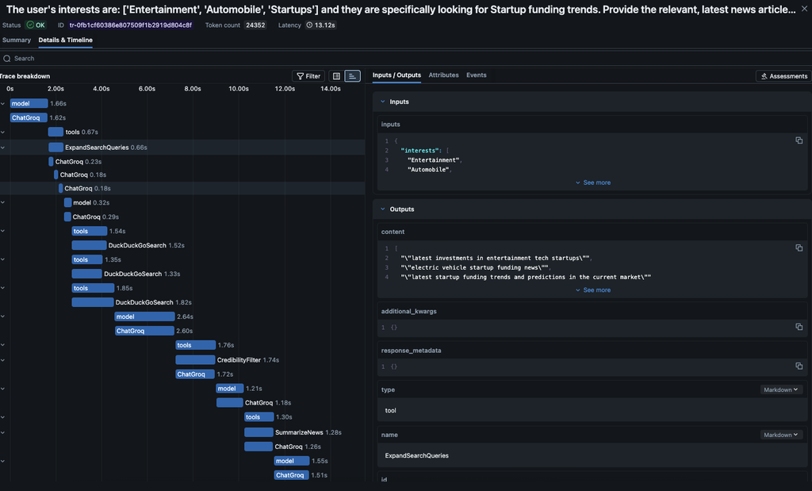

### MLFlow Trace 3

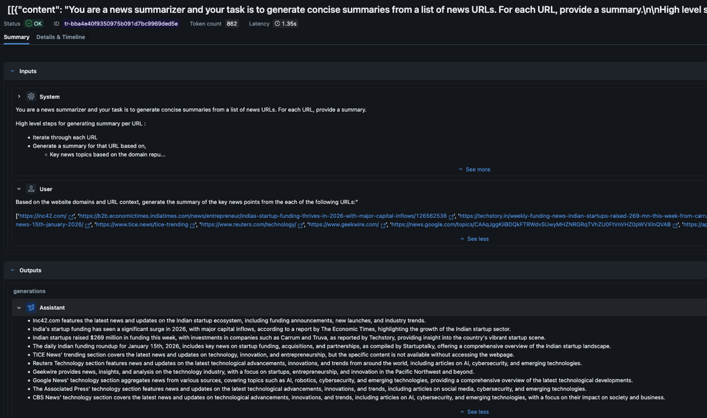

Power Ahead!